# Evictions v. Homelessness Analysis

Sarah Jiang

## Panel Dataset

| variable | label |
| --- | --- |
| state_fips | state FIPS |
| state_name | state name |
| state_abbrev | state abbreviation |
| year | year of observed homeless rate |
| fileyear | = year - 1; year of observed filing rate |
| filerate | Evictions filing rate per 1,000 renting households. |
| homelesscap | Rate of homelessness per 1,000 residents. |
| chroniccap | Chronic homelessness rate per 1,000 residents. |
| red | = 1 if proportion of Republican wins > 60% for Senate elections 1976 - 2020 |
| blue | = 1 if proportion of Democratic wins > 60% for Senate elections 1976 - 2020 |
| densityrank | 2010 Census historical population density ranking |
| dense | = 1 if 2010 Census population density ranking is 26 or lower |

```r
library(haven)
library(MASS)
library(ggplot2)
data = read_dta("homelesspanel.dta")
```

## Summarize, explore & visualize data

The dataset comprises of 452 observations of eviction filings per 1,000 renting households and number of homeless people per 1,000 residents per state per year from 2008 to 2019. Not all states and years are represented. Variables red, blue, densityrank and dense are for the purpose of profiling states and do not vary within each state.

The variable fileyear = year - 1 to stagger filerate and homelesscap as suggested by my professor, since the effects of evictions may not have an immediately observable effect on the state’s population of homeless.

```r
head(data)
```

| state_fips | state_name | state_abbrev | year | fileyear | filerate | homelesscap | chroniccap | red | blue | densityrank | dense |
| --- | --- | --- | --- | --- | --- | --- | --- | --- | --- | --- | --- |
| 1 | ALABAMA | AL | 2008 | 2007 | 19.67213 | 1.1417475 | 0.2229661 | 1 | 0 | 29 | 0 |
| 1 | ALABAMA | AL | 2009 | 2008 | 18.12245 | 1.2778645 | 0.2498982 | 1 | 0 | 29 | 0 |
| 1 | ALABAMA | AL | 2010 | 2009 | 17.50772 | 1.2633961 | 0.2179494 | 1 | 0 | 29 | 0 |
| 1 | ALABAMA | AL | 2011 | 2010 | 18.82511 | 1.1580031 | 0.2179329 | 1 | 0 | 29 | 0 |
| 1 | ALABAMA | AL | 2012 | 2011 | 18.32994 | 1.0814611 | 0.2011779 | 1 | 0 | 29 | 0 |
| 1 | ALABAMA | AL | 2013 | 2012 | 18.68460 | 0.9704888 | 0.1775814 | 1 | 0 | 29 | 0 |

```r
sumstats = summary(data[c('filerate', 'homelesscap', 'chroniccap', 'red', 'blue')])
print(sumstats)
```

```
    filerate       homelesscap       chroniccap           red
 Min.   :  0.00   Min.   :0.4533   Min.   :0.02407   Min.   :0.0000
 1st Qu.: 16.78   1st Qu.:1.0762   1st Qu.:0.13255   1st Qu.:0.0000
 Median : 26.59   Median :1.3083   Median :0.19551   Median :0.0000
 Mean   : 48.76   Mean   :1.7062   Mean   :0.26317   Mean   :0.3739
 3rd Qu.: 48.24   3rd Qu.:1.9936   3rd Qu.:0.30632   3rd Qu.:1.0000
 Max.   :436.37   Max.   :5.5435   Max.   :1.36400   Max.   :1.0000
      blue
 Min.   :0.0000
 1st Qu.:0.0000
 Median :0.0000
 Mean   :0.4381
 3rd Qu.:1.0000
 Max.   :1.0000
```

Let’s take an initial look at the distribution of our main variables of interest, homelesscap and filerate.

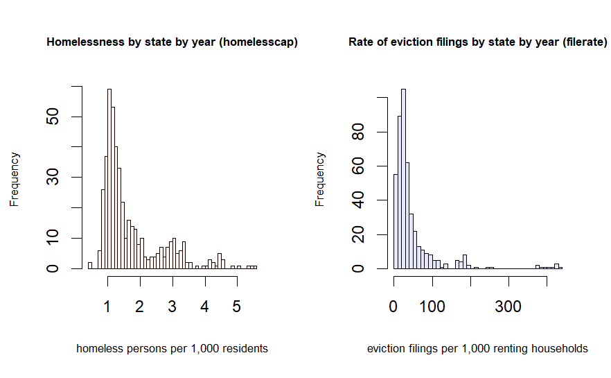

```r
par(mfrow = c(1, 2))

hist(data$homelesscap, breaks = 40, main = "Homelessness by state by year (homelesscap)", xlab = 'homeless persons per 1,000 residents', col = 'seashell', cex.main = 0.7, cex.lab = 0.7)

hist(data$filerate, breaks = 40, main = 'Rate of eviction filings by state by year (filerate)', xlab = 'eviction filings per 1,000 renting households', col = 'lavender', cex.main = 0.7, cex.lab = 0.7)
```

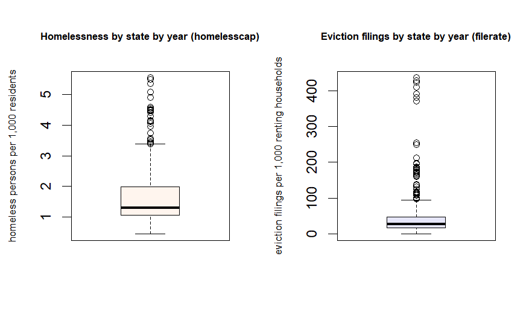

```r
par(mfrow = c(1, 2))

boxplot(data$homelesscap, main = "Homelessness by state by year (homelesscap)", ylab = 'homeless persons per 1,000 residents', cex.main = 0.7, cex.lab = 0.7, col = 'seashell')

boxplot(data$filerate, main = 'Eviction filings by state by year (filerate)', ylab = 'eviction filings per 1,000 renting households', cex.main = 0.7, cex.lab = 0.7, col = 'lavender')
```

The overall distributions of homelesscap and filerate are both very right-skewed and likely multimodal due to states with unique circumstances (the high outlier on filing rates is Maryland).

For now I’m just going to have to do my best with what I know. ** correlation..??? covariance???

## Exploring homelesscap v. filerate

Is there any relationship between eviction filing rates and homelessness?

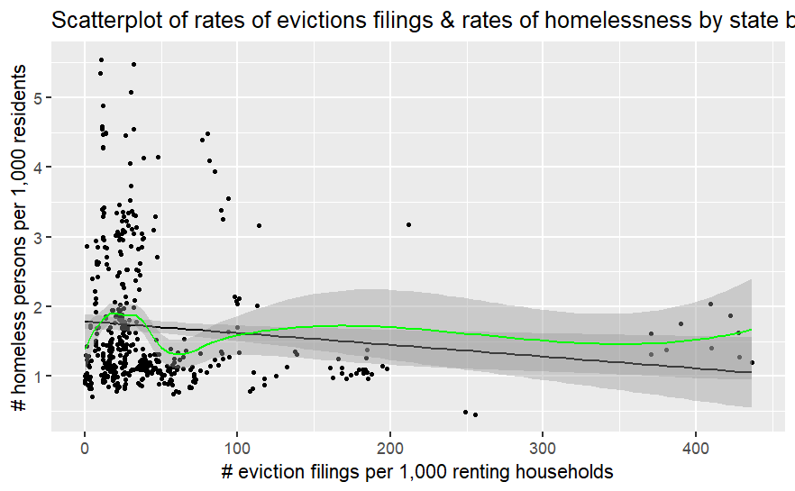

```r
base = ggplot(data = data, mapping = aes(x = filerate, y = homelesscap))

base + geom_point(size = 0.8) +
  geom_smooth(method = 'lm', color = 'black', linewidth = .7) +
  geom_smooth(color = 'green', linewidth = .7) +
  labs(title = 'Scatterplot of rates of evictions filings & rates of homelessness by state by year') +
  ylab('# homeless persons per 1,000 residents') +
  xlab('# eviction filings per 1,000 renting households')
```

$~$

#### Initial simple linear regression

$$\hat{homelesscap}_i = \hat\beta_0 +
\hat\beta_1{filerate}_i + u_i$$

```r
l_model = lm(homelesscap ~ filerate, data = data)
summary(l_model)
```

```
Call:
lm(formula = homelesscap ~ filerate, data = data)

Residuals:
    Min      1Q  Median      3Q     Max
-1.0733 -0.6298 -0.3865  0.3064  3.7729

Coefficients:
              Estimate Std. Error t value Pr(>|t|)
(Intercept)  1.7885208  0.0547680  32.656   <2e-16 ***
filerate    -0.0016871  0.0006542  -2.579   0.0102 *
---
Signif. codes:  0 ‘***’ 0.001 ‘**’ 0.01 ‘*’ 0.05 ‘.’ 0.1 ‘ ’ 1

Residual standard error: 0.9464 on 450 degrees of freedom
Multiple R-squared:  0.01456,   Adjusted R-squared:  0.01237
F-statistic: 6.651 on 1 and 450 DF,  p-value: 0.01023
```

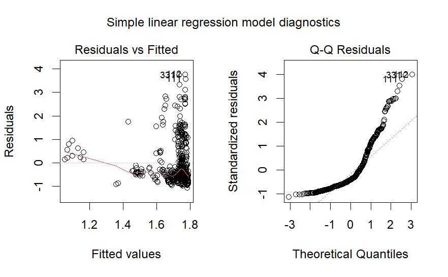

```r
# Plot model diagnostics
par(mfrow=c(1, 2))
plot(l_model, which = 1:2)
mtext('Simple linear regression model diagnostics', side = 3, line = -2, outer = TRUE)
```

From the scatterplot of fitted values and residuals, we can see a clear downward trend in the residual values, showing that the variables $u$ and $\hat{y}$ are not independent. The QQ plot also shows that our error terms are not Normally distributed. These plots confirm that this simple linear specification does not fit our data well.

Let’s add some controls to our model.

$~$

#### Multivariate linear regression

$$\hat{homelesscap}_i = \hat\beta_0 +
\hat\beta_1{filerate}_i + \hat\beta_2{red}_i + \hat\beta_3{blue}_i +
\hat\beta_4{densityrank}_i + u_i$$
****** is it ok to have both red and blue in the model though

```r
lc_model = lm(homelesscap ~ filerate + red + blue + densityrank, data = data)
summary(lc_model)
```

```
Call:
lm(formula = homelesscap ~ filerate + red + blue + densityrank,
    data = data)

Residuals:
    Min      1Q  Median      3Q     Max
-1.3073 -0.6178 -0.2011  0.3514  3.5637

Coefficients:
              Estimate Std. Error t value Pr(>|t|)
(Intercept)  2.0349264  0.1452361  14.011  < 2e-16 ***
filerate    -0.0017913  0.0006871  -2.607  0.00944 **
red         -0.7194097  0.1189287  -6.049 3.08e-09 ***
blue        -0.0692917  0.1176616  -0.589  0.55622
densityrank  0.0022090  0.0033426   0.661  0.50904
---
Signif. codes:  0 ‘***’ 0.001 ‘**’ 0.01 ‘*’ 0.05 ‘.’ 0.1 ‘ ’ 1

Residual standard error: 0.8929 on 447 degrees of freedom
Multiple R-squared:  0.1288,    Adjusted R-squared:  0.121
F-statistic: 16.52 on 4 and 447 DF,  p-value: 1.227e-12
```

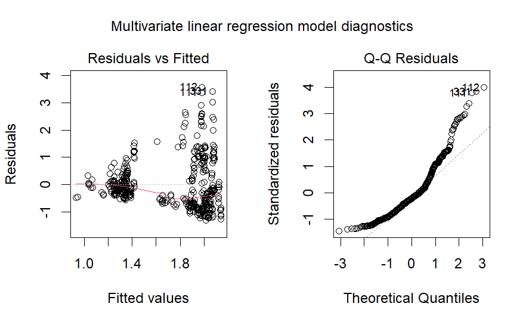

```r
par(mfrow = c(1, 2))
plot(lc_model, which = 1:2)
mtext('Multivariate linear regression model diagnostics', side = 3, line = -2, outer = TRUE)
```

Although the distribution of residuals is still far from what’s desirable, the fit of this model is much improved compared to the previous one judging from the $R^2$. Several of the coefficients in this model are significantly different from 0.

Calculating robust standard errors; however if the model is wrong they won’t be useful

```r
library(lmtest)
library(sandwich)

coeftest(lc_model, vcov = vcovHC, type = "HC1")
```

```
t test of coefficients:

               Estimate  Std. Error t value  Pr(>|t|)
(Intercept)  2.03492643  0.14239741 14.2905 < 2.2e-16 ***
filerate    -0.00179131  0.00053222 -3.3657 0.0008293 ***
red         -0.71940970  0.11409875 -6.3051  6.92e-10 ***
blue        -0.06929168  0.13328670 -0.5199 0.6034119
densityrank  0.00220900  0.00348002  0.6348 0.5259059
---
Signif. codes:  0 ‘***’ 0.001 ‘**’ 0.01 ‘*’ 0.05 ‘.’ 0.1 ‘ ’ 1
```

```r
waldtest(lc_model, terms = "filerate", vcov = vcovHC)
```

```
Wald test

Model 1: homelesscap ~ filerate + red + blue + densityrank
Model 2: homelesscap ~ red + blue + densityrank
  Res.Df Df      F   Pr(>F)
1    447
2    448 -1 10.941 0.001016 **
---
Signif. codes:  0 ‘***’ 0.001 ‘**’ 0.01 ‘*’ 0.05 ‘.’ 0.1 ‘ ’ 1
```

```r
confint(lc_model, "filerate", vcov = vcovHC)
```

```
                2.5 %        97.5 %
filerate -0.003141732 -0.0004408859
```

not sure if my specification is ok. or if we even care about robust standard errors since we almost certainly don’t have the right model. and we’re probbly using the wrong type of robust standard error (HC1). but the hypothesis test and confidence intervals we got suggest that the effect that filerate has one homelesscap is slightly negative and significantly different from 0.

$~$